# Development of taxon group results

Enrique L. Montaño, PhD

Started: July-1-2018

```r
library(tidyverse)
source("R/export_bad_neighbor_list.R")
source("R/state_all_species_query.R")
source("R/state_bad_neighbor_query.R")
source("R/process_bad_neighbor_groups.R")
source("R/generate_bn_count_map.R")
```

This notebook provides an overview of the process of developing taxonomic groups for inclusion in the Bad Neighbor Analysis. This portion of the development uses a USGS non-native species list to verify and qualify results from BISON. The non-native list is not yet published, and will not be used in the final product. However, the BISON query uses these data to indicate non-native status.

## List of taxonomic Classes

Taxonomy does not accurately describe how an end user might approach grouping invasive species. For example, at the Class level, there are 56 entries describing the non-native species. A more intuitive approach might be to group species into informal classifications like tree/shrub. The problem here is there is no one Family or Class that describes this sub-group; hence informal.

The [USDA PLANTS](https://www.plants.usda.gov/about_plants.html) database provides a habitat flag to describe the generalized growth habit of various species like tree, shrub, subshrub, or combinations thereof. Therefore, a list of taxonomic Families that incorporate tree/shrub can be developed from the PLANTS habitat.

A series of families related by habit have been formed and a bad neighbor analysis is run for each of these groups. This portion of the development uses a USGS non-native species list to verify and qualify results from BISON. The non-native list is not yet published, and will not be used in the final product. However, the BISON query uses these data to indicate non-native status.

Each of the informal groups listed below have an associated lookup table for the hierarchy homonym strings: “data/forb_herb_hierarchy_strings.csv”, “data/grasses_hierarchy_strings.csv”, “data/ivy_vines_hierarchy_strings.csv”, “data/tree_shrub_hierarchy_strings.csv”

### Tree/shrub Families

The following runs the analysis using the original, BISON-only query (uses establishmentMeans:L48). The results are similar using an as yet unpublished USGS list of non-native species, and using BISON only is reproducible without needing external lists.

```r
# tree/shrub Families c("Myrtaceae", "Fabaceae", "Ulmaceae", "Rosaceae")

# load lookup tables
taxa <- readr::read_csv("data/tree_shrub_hierarchy_strings.csv")

# run the analysis
trees_results <- process_bad_neighbor_groups("tree_shrub", taxa = taxa)
```

Now we have results for just tree/shrubs. From this result we can use those maps to produce a visualized threat assessment.

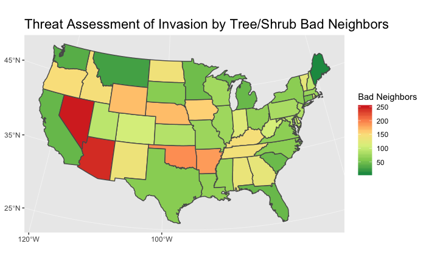

```r
# vector of tree/shrub families
# trees <- c("Myrtaceae", "Fabaceae", "Ulmaceae", "Rosaceae")
# comb_all_results_trees <- purrr::imap_dfr(trees_results, ~ tibble::tibble(
#     taxon = .y,
#     state_name = .x$bad_neighbor$state_name,
#     bad_neighbor_count = .x$bad_neighbor$bad_neighbor_count,
#     state_nn_species_count = .x$bad_neighbor$state_nn_species_count
# ))
# # save the output
# readr::write_csv(comb_all_results_trees, "result_csv/trees_comb_result.csv")
# load in the saved results
comb_all_results_trees <- readr::read_csv("result_csv/trees_comb_result.csv")
# summarize the results to count all tree_shrub species per state
comb_all_results_trees %>%
    group_by(state_name) %>%
    summarize(species_count = sum(bad_neighbor_count)) %>%
    # pass to the plot function
    generate_bn_count_map(taxon = "Tree/Shrub")
```

```r
# save the output
# out_name <- file.path("graphics", stringr::str_c("bad_neighbor_map_", "tree_shrub", ".png", sep = ""))
# ggsave(out_name, height = 6, width = 9)
# print a text report
cat(generate_state_report_text("Alabama", group_name = "Tree/Shrub", comb_all_results_trees))
```

```
Bad Neighbors pose a threat of 131 species of Tree/Shrub that are invasive to Alabama, but are not yet documented within the state.

There are currently 95 species of invasive Tree/Shrub with a documented presence in the state.  Invasive species within Alabama may pose a threat to surrounding states.

Click on a name to open a tab with the species full distribution in <a href='https://bison.usgs.gov' target='_blank'>BISON</a>
```

Now process the other types

### Forb/Herbs

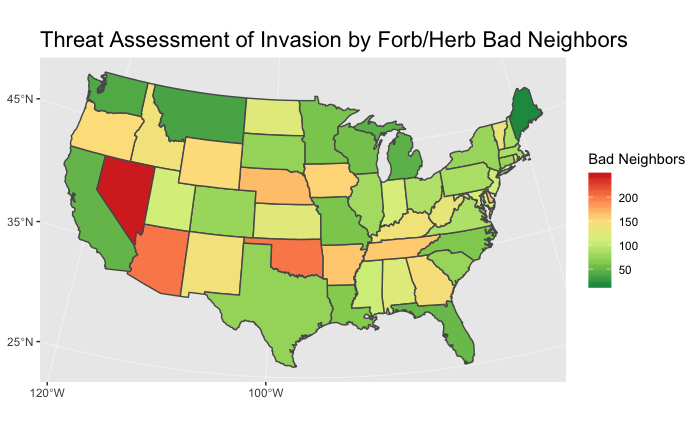

```r
# Forb/herb Families c("Asteraceae", "Pteridaceae", "Onagraceae", "Lamiaceae")
# load lookup tables
# taxa <- readr::read_csv("data/forb_herb_heirarchy_strings.csv")
# forbs_results <- process_bad_neighbor_groups("forbs_herbs", taxa = taxa)
#
# comb_all_results_forbs <- purrr::imap_dfr(forbs_results, ~ tibble::tibble(
#     taxon = .y,
#     state_name = .x$bad_neighbor$state_name,
#     bad_neighbor_count = .x$bad_neighbor$bad_neighbor_count,
#     state_nn_species_count = .x$bad_neighbor$state_nn_species_count
# ))
#
# # save the result
# readr::write_csv(comb_all_results_forbs, "result_csv/forbs_comb_result.csv")
# load the saved file
comb_all_results_forbs <- readr::read_csv("result_csv/forbs_comb_result.csv")
# summarize the results to count all tree_shrub species per state
comb_all_results_forbs %>%
    group_by(state_name) %>%
    summarize(species_count = sum(bad_neighbor_count)) %>%
    # pass to the plot function
    generate_bn_count_map(taxon = "Forb/Herb")
```

```r
# save the output
# out_name <- file.path("graphics", stringr::str_c("bad_neighbor_map_", "forb_herbs", ".png", sep = ""))
# ggsave(out_name, height = 6, width = 9)
```

### Vines/ivy

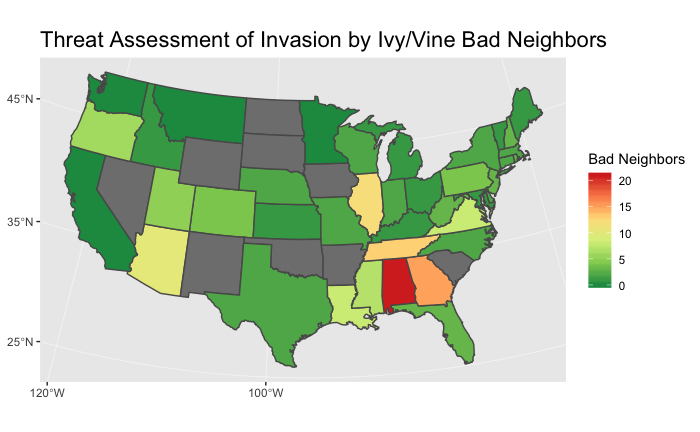

```r
# vine Families c("Araceae", "Anacardiaceae", "Vitaceae")
# load lookup tables
# taxa <- readr::read_csv("data/ivy_vines_heirarchy_strings.csv")
#
# ivy_results <- process_bad_neighbor_groups("ivy_vines", taxa = taxa)
#
# comb_all_results_ivy <- purrr::imap_dfr(ivy_results, ~ tibble::tibble(
#     taxon = .y,
#     state_name = .x$bad_neighbor$state_name,
#     bad_neighbor_count = .x$bad_neighbor$bad_neighbor_count,
#     state_nn_species_count = .x$bad_neighbor$state_nn_species_count
# ))
# save the result
# readr::write_csv(comb_all_results_ivy, "result_csv/ivy_comb_result.csv")
# load the saved file
comb_all_results_ivy <- readr::read_csv("result_csv/ivy_comb_result.csv")
# summarize the results to count all tree_shrub species per state
comb_all_results_ivy %>%
    group_by(state_name) %>%
    summarize(species_count = sum(bad_neighbor_count)) %>%
    # pass to the plot function
    generate_bn_count_map(taxon = "Ivy/Vine")
```

```r
# save the output
# out_name <- file.path("graphics", stringr::str_c("bad_neighbor_map_", "ivy_vines", ".png", sep = ""))
# ggsave(out_name, height = 6, width = 9)
```

### Grasses

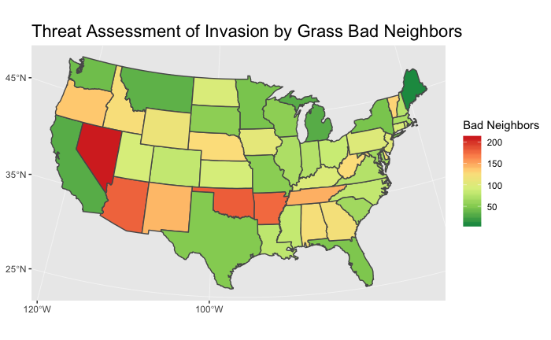

```r
# Gras Families  c("Cyperaceae", "Poaceae")
# load lookup tables
# taxa <- readr::read_csv("data/grasses_heirarchy_strings.csv")
#
# grasses_results <- process_bad_neighbor_groups("grasses", taxa = taxa)
#
# comb_all_results_grasses <- purrr::imap_dfr(grasses_results, ~ tibble::tibble(
#     taxon = .y,
#     state_name = .x$bad_neighbor$state_name,
#     bad_neighbor_count = .x$bad_neighbor$bad_neighbor_count,
#     state_nn_species_count = .x$bad_neighbor$state_nn_species_count
# ))
#
# # save the result
# readr::write_csv(comb_all_results_grasses, "result_csv/grasses_comb_result.csv")
# load the saved file
comb_all_results_grasses <- readr::read_csv("result_csv/grasses_comb_result.csv")
# summarize the results to count all tree_shrub species per state
comb_all_results_grasses %>%
    group_by(state_name) %>%
    summarize(species_count = sum(bad_neighbor_count)) %>%
    # pass to the plot function
    generate_bn_count_map(taxon = "Grass")
```

```r
# save the output
# out_name <- file.path("graphics", stringr::str_c("bad_neighbor_map_", "grasses", ".png", sep = ""))
# ggsave(out_name, height = 6, width = 9)
```

### Birds

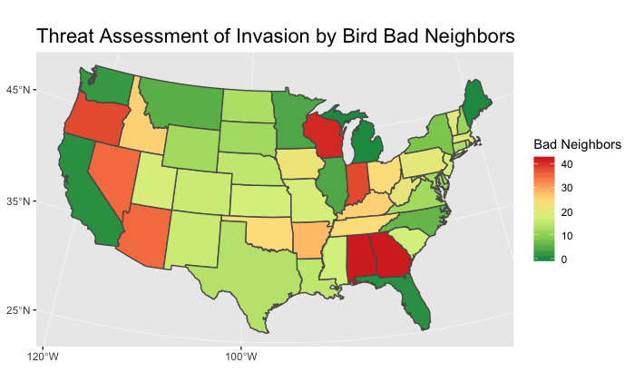

```r
# taxa <- readr::read_csv("data/heirarchy_strings.csv")
# process the insect taxa, record 1
# birds_results <- process_bad_neighbor_groups("bird", taxa = taxa[1,])
# #
# comb_all_results_birds <- purrr::imap_dfr(birds_results, ~ tibble::tibble(
#     taxon = .y,
#     state_name = .x$bad_neighbor$state_name,
#     bad_neighbor_count = .x$bad_neighbor$bad_neighbor_count,
#     state_nn_species_count = .x$bad_neighbor$state_nn_species_count
# ))
#
# # save the result
# readr::write_csv(comb_all_results_birds, "result_csv/birds_comb_result.csv")
# load the saved file
comb_all_results_birds <- readr::read_csv("result_csv/birds_comb_result.csv")
# summarize the results to count all tree_shrub species per state
comb_all_results_birds %>%
    group_by(state_name) %>%
    summarize(species_count = sum(bad_neighbor_count)) %>%
    # pass to the plot function
    generate_bn_count_map(taxon = "Bird")
```

```r
# save the output
# out_name <- file.path("graphics", stringr::str_c("bad_neighbor_map_", "birds", ".png", sep = ""))
# ggsave(out_name, height = 6, width = 9)
```

### Insects

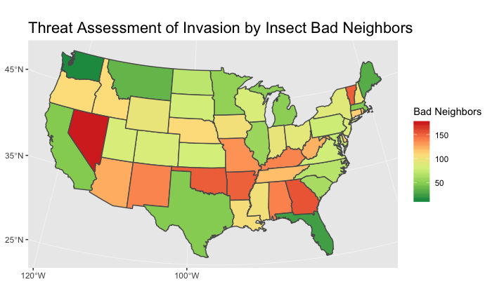

```r
# load lookup tables
# taxa <- readr::read_csv("data/heirarchy_strings.csv")
#
# # process the insect taxa, record 3
# insects_results <- process_bad_neighbor_groups("insect", taxa = taxa[3,])
# #
# comb_all_results_insects <- purrr::imap_dfr(insects_results, ~ tibble::tibble(
#     taxon = .y,
#     state_name = .x$bad_neighbor$state_name,
#     bad_neighbor_count = .x$bad_neighbor$bad_neighbor_count,
#     state_nn_species_count = .x$bad_neighbor$state_nn_species_count
# ))
#
# # save the result
# readr::write_csv(comb_all_results_insects, "result_csv/insects_comb_result.csv")
# load the saved file
comb_all_results_insects <- readr::read_csv("result_csv/insects_comb_result.csv")
# summarize the results to count all tree_shrub species per state
comb_all_results_insects %>%
    group_by(state_name) %>%
    summarize(species_count = sum(bad_neighbor_count)) %>%
    # pass to the plot function
    generate_bn_count_map(taxon = "Insect")
```

```r
# save the output
# out_name <- file.path("graphics", stringr::str_c("bad_neighbor_map_", "insects", ".png", sep = ""))
# ggsave(out_name, height = 6, width = 9)
```

## Summaries

What contribution does each group make to the total of bad neighbor plants?

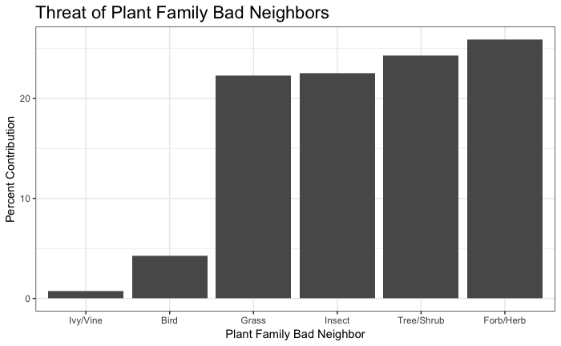

```r
# trees
# sum_trees <- comb_all_results_trees %>%
#     group_by(state_name) %>%
#     summarize(bad_neighbor_count = sum(bad_neighbor_count), state_nn_species_count = sum(state_nn_species_count)) %>%
#     mutate(family = "Tree/Shrub")
#
# # forbs
# sum_forbs <- comb_all_results_forbs %>%
#     group_by(state_name) %>%
#     summarize(bad_neighbor_count = sum(bad_neighbor_count), state_nn_species_count = sum(state_nn_species_count)) %>%
#     mutate(family = "Forb/Herb")
#
# # grasses
# sum_grasses <- comb_all_results_grasses %>%
#     group_by(state_name) %>%
#     summarize(bad_neighbor_count = sum(bad_neighbor_count), state_nn_species_count = sum(state_nn_species_count)) %>%
#     mutate(family = "Grass")
#
# # vines
# sum_ivy <- comb_all_results_ivy %>%
#     group_by(state_name) %>%
#     summarize(bad_neighbor_count = sum(bad_neighbor_count), state_nn_species_count = sum(state_nn_species_count)) %>%
#     mutate(family = "Ivy/Vine")
#
# # birds
# sum_birds <- comb_all_results_birds %>%
#     group_by(state_name) %>%
#     summarize(bad_neighbor_count = sum(bad_neighbor_count), state_nn_species_count = sum(state_nn_species_count)) %>%
#     mutate(family = "Bird")
#
# # insects
# sum_insects <- comb_all_results_insects %>%
#     group_by(state_name) %>%
#     summarize(bad_neighbor_count = sum(bad_neighbor_count), state_nn_species_count = sum(state_nn_species_count)) %>%
#     mutate(family = "Insect")
#
#
# # combine all
# comb_all_results <- bind_rows(sum_trees, sum_ivy, sum_forbs, sum_grasses, sum_birds, sum_insects)
#
# # save the results
# readr::write_csv(comb_all_results, "result_csv/combine_all_plant_bad_neighbor.csv")
# load the results
comb_all_results <- readr::read_csv("result_csv/combine_all_plant_bad_neighbor.csv")
comb_all_results %>%
    group_by(family) %>% # group by family
    summarise(contrib_bad_neighbor = sum(bad_neighbor_count)) %>%  # calculate the sum of each group
    mutate(pct_contrib_bad_neighbor = (contrib_bad_neighbor / sum(contrib_bad_neighbor) * 100)) %>%
    ggplot(aes(x = reorder(family, pct_contrib_bad_neighbor), y = pct_contrib_bad_neighbor)) +
    geom_bar(stat = "identity") +
    # geom_text(aes(label = paste0(pct_contrib_bad_neighbor, "%"), y = pct_contrib_bad_neighbor),
            # vjust = 1.4, size = 5, color = "white") +
    labs(title = "Threat of Plant Family Bad Neighbors",
         x = "Plant Family Bad Neighbor",
         y = "Percent Contribution") +
    # ggthemes::theme_tufte()
    theme_bw() +
    theme(plot.title = ggplot2::element_text(size = ggplot2::rel(1.5)))
```

```r
NA
```